# Compare sorters with some dataset generated with MEArec

@author : Samuel Garcia

Alessio Paolo Buccino author of MEArec have generated a dataset with ground truth. The simulated probe is **SqMEA-10-15**.

It is a very dense probe. The duration is 60s.

The file **recordings_50cells_SqMEA-10-15um_60.0_10.0uV_27-03-2019_13_31.h5** is (will be) freely downloadable to reproduce results.

This notebook is is demonstration of the spiketoolkit ground truth comparison framework. It launch several popular sorter on this recording and compute some performence metrics.

The goal of this is **not** to rank sorter because some have then have certainly non optimal parameters for this particular dataset. The goal is to explore strength but mainly weekness of each sorters.

```python
import time

import pandas as pd
import matplotlib.pyplot as plt
import seaborn as sns

import spiketoolkit as st
import spikeextractors as se
from spiketoolkit.study import GroundTruthStudy

import MEAutility as mu
import MEArec as mr

# %matplotlib notebook
%matplotlib inline
plt.rcParams['figure.figsize'] = [12, 8]
```

```python
# p = '/media/samuel/SamCNRS/DataSpikeSorting/mearec/'
p = '/home/samuel/DataSpikeSorting/mearec/'
# p = '/media/samuel/dataspikesorting/DataSpikeSortingHD2/mearec/'

study_folder = p + 'study_mearec'

mearec_filename = p + 'recordings_50cells_SqMEA-10-15um_60.0_10.0uV_27-03-2019_13_31.h5'
```

```python
rec0  = se.MEArecRecordingExtractor(mearec_filename, locs_2d=False)
gt_sorting0 = se.MEArecSortingExtractor(mearec_filename)
```

# Inspect the dataset

Before, making the dataset lets explore probe geometry and grdound truth templates.

The signal are simulated using MEArec written by Alessio Buccino.

- It is a **very dense** probe using the shape **SqMEA-10-15**.
- The probe have 10 X 10 channels.
- There are **50** templates = **50** ground truth units.
- As the array is dense, template have a high spatial definition and redundency.

MEAutility and MEArec offer easy to use plotting functions.

### Probe

```python
# load the mearec file
recgen = mr.load_recordings(mearec_filename)
```

```
Text(0.5,1,'SqMEA-10-15um')
```

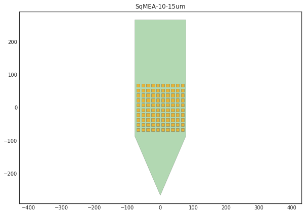

```python
# plot the probe
probe_info = recgen.info['electrodes']
probe_name = recgen.info['electrodes']['electrode_name']
mea = mu.return_mea(info=probe_info)
fig, ax = plt.subplots()
mu.plot_probe(mea, ax=ax)
ax.set_title(probe_name)
```

### Some ground truth templates

Here a selection of 12 template out of 50.

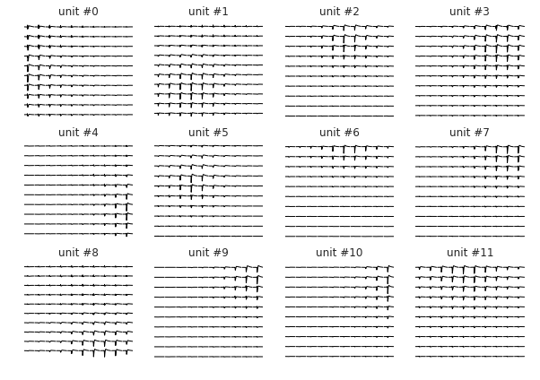

```python
fig, axs = plt.subplots(nrows=3, ncols=4)
for i, unit_id in enumerate(gt_sorting0.get_unit_ids()[:12]):
    ax = axs.flatten()[i]
    mr.plot_templates(recgen, template_ids=unit_id, ax=ax)
    ax.set_title('unit #{}'.format(unit_id))
```

### Compute template SNR

Spiketookit have utilities to compute the peak of each template. This is quite long so we save the results into a datataframe with xlsx format.

For the peak SNR is done as follow:

- compute the median template with the ground truth indexes
- detect where is the max channel.
- get the peak amplitude
- compute the MAD on the filtered signals on a fraction of the signal.
- **snr = peak_amplitude / mad_of_the_channel**

lets do the prediction that units with SNR of 3 will be "hard" to detect and sort :).

```python
snr = st.validation.compute_unit_SNR(rec0, gt_sorting0)
snr = pd.Series(snr, index=gt_sorting0.get_unit_ids())
snr.name = 'snr'
pd.DataFrame(snr).to_excel(p + 'units_snr.xlsx')
```

```python
snr = pd.read_excel(p + 'units_snr.xlsx', index_col=0)['snr']
```

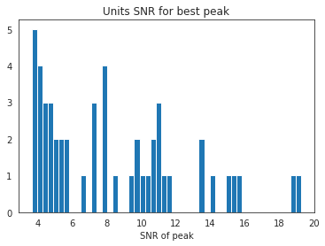

```python
fig, ax = plt.subplots()
ax.hist(snr, bins=50)
ax.set_title('Units SNR for best peak')
ax.set_xlabel('SNR of peak')
```

## Step 1 : setup study folder

The function **setup_comparison_study** of spiketoolkit create a "study folder" with evrything copied inside. The input is a dict of (recording + gt_sorting). Recording been the spikeextractor object representing traces and gt_sorting been the spikeextractor object representing the spike index of each units.

We need first to downloaded in the current directory.

Note: this file have a 3D geometry for teh probe. Many sorters work only with 2D. So here we remove the first dimenssion of "location" in the recording.

```python
# this is a small trick to make the probe geometry planar.
for chan in rec0.get_channel_ids():
    loc = rec0.get_channel_property(chan, 'location')
    rec0.set_channel_property(chan, 'location', loc[1:])

gt_dict = {'rec0' : (rec0, gt_sorting0) }

study = GroundTruthStudy.setup(study_folder, gt_dict)
```

## Step 2 : run all sorter

This run all sorter on all recording and store the results in a working folder.

- of course this simple cells take hours to be computed. So when it is done never execute this again.
- if a sorter is failing you can launch it again the 'keep' arg prevent recompute again.

```python
# ironclust isleft because the wrapper is buggy and klusta do not scale correctly for 100 chans
sorter_list = ['tridesclous', 'herdingspikes', 'mountainsort4', 'spykingcircus', 'kilosort', 'kilosort2', 'klusta']
study = GroundTruthStudy(study_folder)
study.run_sorters(sorter_list, mode='keep', engine='loop')
```

## Step3 : collect comparisons

spiketoolkit offer a GroundTruthComparison class that take a gt_sorting and a tested_sorting as input. This class do:

- match units between GT and tested
- count FP/TP/FN/CL
- compute the confusion matrix
- make some performance table.

When we run a "study", the function **aggregate_sorting_comparison** collect of all **(rec_name, sorter_name)** pair and apply the GroundTruthComparison class for each.

So we have at once all comparison for all sorter for all recordings. We can then exploit this to analyse results.

```python
study = GroundTruthStudy(study_folder)
study.run_comparisons(exhaustive_gt=True)
comparisons = study.comparisons
```

## plot confusion matrix

The most important but quite verbose step to do is to look at confusion matrix between ground truth and sorter units:

Unfortunatly this big matrix are very diffuclt to inspect because we have to many units. By zooming then we can have a clear overviwe on the situation

Some rules to interpret this matrix:

- square matrix with evry thing on the diagonal is the perfect situation.
- vertical elongatated matrix means, but with a dialog in upper part is some units are detected some other no
- horizontal elongated matrix means, the sorter detect too much units. More than the ground truth. wich is exhaustive here.
- have a look on the FP line and FN columns.
- spike out the diagonal is missclassification (CL)

See https://en.wikipedia.org/wiki/Confusion_matrix

```
rec0 klusta
rec0 kilosort
rec0 herdingspikes
rec0 kilosort2
rec0 spykingcircus
```

```
rec0 tridesclous
```

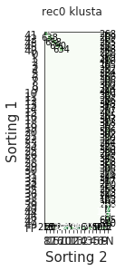

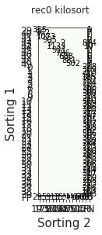

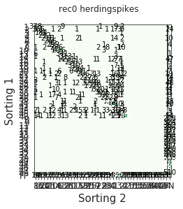

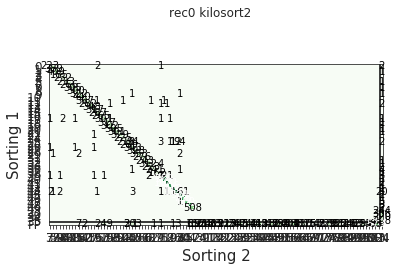

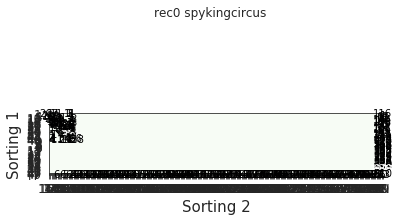

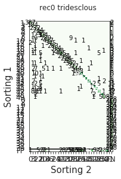

```python
for (rec_name, sorter_name), comp in comparisons.items():
    print(rec_name, sorter_name)
    fig, ax = plt.subplots()
    comp.plot_confusion_matrix(ax=ax)
    fig.suptitle(rec_name + ' ' + sorter_name)
```

## print summary and average perf

To summary performence each GroundTruthComparison can print performance and a summary.

```python
for (rec_name, sorter_name), comp in comparisons.items():
    print('*'*40)
    print(rec_name, sorter_name)
    print('*'*40)
    comp.print_summary()
    comp.print_performance('pooled_with_average')
```

```
rec0 klusta
SUMMARY
GT num_units: 50
TESTED num_units: 16
num_well_detected: 0
num_redundant: 0
num_false_positive_units 0
num_bad: 11

PERFORMANCE
Method : pooled_with_average

ACCURACY: 6.760951649045929
RECALL: 7.281469993980179
PRECISION: 90.9023707826402
FALSE DISCOVERY RATE: 9.097629217359776
MISS RATE: 92.71853000601982
MISS CLASSIFICATION RATE: 0.0

rec0 kilosort
SUMMARY
GT num_units: 50
TESTED num_units: 15
num_well_detected: 7
num_redundant: 0
num_false_positive_units 0
num_bad: 4

PERFORMANCE
Method : pooled_with_average

ACCURACY: 17.937860367153935
RECALL: 19.906628935907463
PRECISION: 81.85324699921523
FALSE DISCOVERY RATE: 18.146753000784763
MISS RATE: 80.00784471928556
MISS CLASSIFICATION RATE: 0.09429376178878782

rec0 herdingspikes
SUMMARY
```

[output cut: 58 more lines]

```
TESTED num_units: 32
num_well_detected: 18
num_redundant: 0
num_false_positive_units 0
num_bad: 2

PERFORMANCE
Method : pooled_with_average

ACCURACY: 53.382813186650466
RECALL: 59.61566710054671
PRECISION: 89.47733106743215
FALSE DISCOVERY RATE: 10.522668932567852
MISS RATE: 40.38109055483243
MISS CLASSIFICATION RATE: 0.3352191980119521
```

## Step 4 : collect tables

spiketoolkit propos ethe function **aggregate_performances_table** to concatenate several table of performance.

**dataframes** is a dict that contain several results formated in dataframes:

- run_times : time for computing each one
- perf_pooled_with_sum: performance with method **pooled_with_sum**
- perf_pooled_with_average: performance with method **pooled_with_average**
- nb_units_above_threshold: count how many units detect with a treshold on a perf columns.
- perf_by_spiketrain: the most convinient one perf at units level

```python
%%capture --no-display
dataframes = study.aggregate_dataframes()
```

```python
dataframes['perf_pooled_with_average']
```

| rec_name | sorter_name | accuracy | recall | precision | false_discovery_rate | miss_rate | misclassification_rate |
| --- | --- | --- | --- | --- | --- | --- | --- |
| rec0 | herdingspikes | 0.536666 | 0.576064 | 0.897008 | 0.102992 | 0.42142 | 0.0198142 |
|  | klusta | 0.0676095 | 0.0728147 | 0.909024 | 0.0909763 | 0.927185 | 0 |
|  | tridesclous | 0.533828 | 0.596157 | 0.894773 | 0.105227 | 0.403811 | 0.00335219 |
|  | kilosort | 0.179379 | 0.199066 | 0.818532 | 0.181468 | 0.800078 | 0.000942938 |
|  | kilosort2 | 0.897439 | 0.917387 | 0.978227 | 0.0217732 | 0.0825369 | 0.00895285 |
|  | spykingcircus | 0.314492 | 0.315895 | 0.991791 | 0.00820865 | 0.682318 | 0.00540255 |

```python
dataframes['count_units']
```

| rec_name | sorter_name | num_gt | num_sorter | num_well_detected | num_redundant | num_false_positive | num_bad |
| --- | --- | --- | --- | --- | --- | --- | --- |
| rec0 | herdingspikes | 50 | 45 | 12 | 1 | 0 | 14 |
|  | klusta | 50 | 16 | 0 | 0 | 0 | 11 |
|  | tridesclous | 50 | 32 | 18 | 0 | 0 | 2 |
|  | kilosort | 50 | 15 | 7 | 0 | 0 | 4 |
|  | kilosort2 | 50 | 105 | 43 | 3 | 2 | 59 |
|  | spykingcircus | 50 | 274 | 2 | 2 | 62 | 252 |

## Step 5: inspect result by unit

For finer exploration, we can also retrieve for all **(rec_name, sorter_name)** pair the raw count unit by unit for each sorter.

This give a give result for each units of the ground truth.

```python
for (rec_name, sorter_name), comp in comparisons.items():
    print(rec_name, sorter_name)
    perf = comp.get_performance(method='raw_count')
    display(perf)
```

```
rec0 klusta
```

| gt_unit_id | tp | fn | cl | fp | num_gt | num_tested | tested_id |
| --- | --- | --- | --- | --- | --- | --- | --- |
| 0 | 0 | 228 | 0 | 0 | 228 | 0 | -1 |
| 1 | 0 | 389 | 0 | 0 | 389 | 0 | -1 |
| 2 | 0 | 410 | 0 | 0 | 410 | 0 | -1 |
| 3 | 0 | 185 | 0 | 0 | 185 | 0 | -1 |
| 4 | 0 | 232 | 0 | 0 | 232 | 0 | -1 |
| 5 | 0 | 234 | 0 | 0 | 234 | 0 | -1 |
| 6 | 0 | 266 | 0 | 0 | 266 | 0 | -1 |
| 7 | 0 | 306 | 0 | 0 | 306 | 0 | -1 |
| 8 | 0 | 300 | 0 | 0 | 300 | 0 | -1 |
| 9 | 0 | 324 | 0 | 0 | 324 | 0 | -1 |
| 10 | 0 | 440 | 0 | 0 | 440 | 0 | -1 |
| 11 | 0 | 369 | 0 | 0 | 369 | 0 | -1 |
| 12 | 0 | 286 | 0 | 0 | 286 | 0 | -1 |
| 13 | 0 | 348 | 0 | 0 | 348 | 0 | -1 |
| 14 | 0 | 317 | 0 | 0 | 317 | 0 | -1 |
| 15 | 0 | 287 | 0 | 0 | 287 | 0 | -1 |
| 16 | 0 | 265 | 0 | 0 | 265 | 0 | -1 |
| 17 | 0 | 307 | 0 | 0 | 307 | 0 | -1 |
| 18 | 0 | 318 | 0 | 0 | 318 | 0 | -1 |
| 19 | 0 | 302 | 0 | 0 | 302 | 0 | -1 |
| 20 | 0 | 506 | 0 | 0 | 506 | 0 | -1 |
| 21 | 0 | 302 | 0 | 0 | 302 | 0 | -1 |
| 22 | 0 | 330 | 0 | 0 | 330 | 0 | -1 |
| 23 | 0 | 244 | 0 | 0 | 244 | 0 | -1 |
| 24 | 0 | 225 | 0 | 0 | 225 | 0 | -1 |
| 25 | 0 | 330 | 0 | 0 | 330 | 0 | -1 |
| 26 | 0 | 289 | 0 | 0 | 289 | 0 | -1 |
| 27 | 0 | 345 | 0 | 0 | 345 | 0 | -1 |
| 28 | 0 | 328 | 0 | 0 | 328 | 0 | -1 |
| 29 | 0 | 356 | 0 | 0 | 356 | 0 | -1 |
| 30 | 0 | 306 | 0 | 0 | 306 | 0 | -1 |
| 31 | 0 | 276 | 0 | 0 | 276 | 0 | -1 |
| 32 | 0 | 244 | 0 | 0 | 244 | 0 | -1 |
| 33 | 0 | 317 | 0 | 0 | 317 | 0 | -1 |
| 34 | 0 | 220 | 0 | 0 | 220 | 0 | -1 |
| 35 | 0 | 258 | 0 | 0 | 258 | 0 | -1 |
| 36 | 0 | 223 | 0 | 0 | 223 | 0 | -1 |
| 37 | 0 | 246 | 0 | 0 | 246 | 0 | -1 |
| 38 | 0 | 163 | 0 | 0 | 163 | 0 | -1 |
| 39 | 0 | 298 | 0 | 0 | 298 | 0 | -1 |
| 40 | 0 | 970 | 0 | 0 | 970 | 0 | -1 |
| 41 | 805 | 268 | 0 | 213 | 1073 | 1018 | 8 |
| 42 | 638 | 269 | 0 | 6 | 907 | 644 | 17 |
| 43 | 658 | 255 | 0 | 202 | 913 | 860 | 15 |
| 44 | 0 | 1143 | 0 | 0 | 1143 | 0 | -1 |
| 45 | 690 | 233 | 0 | 1 | 923 | 691 | 16 |
| 46 | 0 | 786 | 0 | 0 | 786 | 0 | -1 |
| 47 | 0 | 695 | 0 | 0 | 695 | 0 | -1 |
| 48 | 634 | 248 | 0 | 0 | 882 | 634 | 7 |
| 49 | 0 | 510 | 0 | 0 | 510 | 0 | -1 |

```
rec0 kilosort
```

| gt_unit_id | tp | fn | cl | fp | num_gt | num_tested | tested_id |
| --- | --- | --- | --- | --- | --- | --- | --- |
| 0 | 0 | 228 | 0 | 0 | 228 | 0 | -1 |
| 1 | 0 | 389 | 0 | 0 | 389 | 0 | -1 |
| 2 | 0 | 410 | 0 | 0 | 410 | 0 | -1 |
| 3 | 0 | 185 | 0 | 0 | 185 | 0 | -1 |
| 4 | 0 | 232 | 0 | 0 | 232 | 0 | -1 |
| 5 | 0 | 234 | 0 | 0 | 234 | 0 | -1 |
| 6 | 0 | 266 | 0 | 0 | 266 | 0 | -1 |
| 7 | 0 | 306 | 0 | 0 | 306 | 0 | -1 |
| 8 | 0 | 300 | 0 | 0 | 300 | 0 | -1 |
| 9 | 0 | 324 | 0 | 0 | 324 | 0 | -1 |
| 10 | 0 | 440 | 0 | 0 | 440 | 0 | -1 |
| 11 | 0 | 369 | 0 | 0 | 369 | 0 | -1 |
| 12 | 0 | 286 | 0 | 0 | 286 | 0 | -1 |
| 13 | 0 | 348 | 0 | 0 | 348 | 0 | -1 |
| 14 | 0 | 317 | 0 | 0 | 317 | 0 | -1 |
| 15 | 0 | 287 | 0 | 0 | 287 | 0 | -1 |
| 16 | 0 | 265 | 0 | 0 | 265 | 0 | -1 |
| 17 | 0 | 307 | 0 | 0 | 307 | 0 | -1 |
| 18 | 0 | 318 | 0 | 0 | 318 | 0 | -1 |
| 19 | 0 | 302 | 0 | 0 | 302 | 0 | -1 |
| 20 | 0 | 506 | 0 | 0 | 506 | 0 | -1 |
| 21 | 0 | 302 | 0 | 0 | 302 | 0 | -1 |
| 22 | 0 | 330 | 0 | 0 | 330 | 0 | -1 |
| 23 | 0 | 244 | 0 | 0 | 244 | 0 | -1 |
| 24 | 0 | 225 | 0 | 0 | 225 | 0 | -1 |
| 25 | 0 | 330 | 0 | 0 | 330 | 0 | -1 |
| 26 | 0 | 289 | 0 | 0 | 289 | 0 | -1 |
| 27 | 0 | 345 | 0 | 0 | 345 | 0 | -1 |
| 28 | 0 | 328 | 0 | 0 | 328 | 0 | -1 |
| 29 | 355 | 1 | 0 | 295 | 356 | 652 | 193 |
| 30 | 0 | 306 | 0 | 0 | 306 | 0 | -1 |
| 31 | 0 | 276 | 0 | 0 | 276 | 0 | -1 |
| 32 | 0 | 244 | 0 | 0 | 244 | 0 | -1 |
| 33 | 0 | 317 | 0 | 0 | 317 | 0 | -1 |
| 34 | 0 | 220 | 0 | 0 | 220 | 0 | -1 |
| 35 | 0 | 258 | 0 | 0 | 258 | 0 | -1 |
| 36 | 0 | 223 | 0 | 0 | 223 | 0 | -1 |
| 37 | 0 | 246 | 0 | 0 | 246 | 0 | -1 |
| 38 | 0 | 163 | 0 | 0 | 163 | 0 | -1 |
| 39 | 0 | 298 | 0 | 0 | 298 | 0 | -1 |
| 40 | 962 | 7 | 1 | 0 | 970 | 962 | 172 |
| 41 | 1073 | 0 | 0 | 0 | 1073 | 1073 | 736 |
| 42 | 905 | 2 | 0 | 0 | 907 | 905 | 53 |
| 43 | 0 | 874 | 39 | 913 | 913 | 913 | 135 |
| 44 | 1133 | 10 | 0 | 1 | 1143 | 1134 | 115 |
| 45 | 921 | 2 | 0 | 0 | 923 | 921 | 402 |
| 46 | 786 | 0 | 0 | 55 | 786 | 841 | 41 |
| 47 | 688 | 6 | 1 | 5 | 695 | 693 | 751 |
| 48 | 881 | 1 | 0 | 14 | 882 | 895 | 470 |
| 49 | 502 | 7 | 1 | 416 | 510 | 920 | 351 |

```
rec0 herdingspikes
```

| gt_unit_id | tp | fn | cl | fp | num_gt | num_tested | tested_id |
| --- | --- | --- | --- | --- | --- | --- | --- |
| 0 | 0 | 228 | 0 | 0 | 228 | 0 | -1 |
| 1 | 378 | 0 | 11 | 14 | 389 | 404 | 8 |
| 2 | 366 | 24 | 20 | 18 | 410 | 388 | 16 |
| 3 | 184 | 0 | 1 | 40 | 185 | 227 | 30 |
| 4 | 232 | 0 | 0 | 3 | 232 | 237 | 24 |
| 5 | 216 | 10 | 8 | 42 | 234 | 258 | 32 |
| 6 | 266 | 0 | 0 | 8 | 266 | 274 | 23 |
| 7 | 299 | 4 | 3 | 27 | 306 | 335 | 10 |
| 8 | 286 | 0 | 14 | 12 | 300 | 317 | 14 |
| 9 | 0 | 324 | 0 | 0 | 324 | 0 | -1 |
| 10 | 436 | 0 | 4 | 8 | 440 | 452 | 6 |
| 11 | 0 | 369 | 0 | 0 | 369 | 0 | -1 |
| 12 | 0 | 286 | 0 | 0 | 286 | 0 | -1 |
| 13 | 341 | 1 | 6 | 6 | 348 | 359 | 13 |
| 14 | 313 | 0 | 4 | 47 | 317 | 379 | 12 |
| 15 | 221 | 47 | 19 | 34 | 287 | 255 | 26 |
| 16 | 256 | 5 | 4 | 27 | 265 | 288 | 20 |
| 17 | 0 | 307 | 0 | 0 | 307 | 0 | -1 |
| 18 | 310 | 0 | 8 | 9 | 318 | 322 | 11 |
| 19 | 294 | 4 | 4 | 10 | 302 | 307 | 17 |
| 20 | 491 | 0 | 15 | 11 | 506 | 506 | 5 |
| 21 | 266 | 19 | 17 | 6 | 302 | 274 | 18 |
| 22 | 227 | 74 | 29 | 25 | 330 | 256 | 29 |
| 23 | 0 | 244 | 0 | 0 | 244 | 0 | -1 |
| 24 | 216 | 4 | 5 | 32 | 225 | 248 | 25 |
| 25 | 258 | 48 | 24 | 22 | 330 | 290 | 15 |
| 26 | 270 | 11 | 8 | 27 | 289 | 307 | 19 |
| 27 | 320 | 4 | 21 | 40 | 345 | 372 | 7 |
| 28 | 309 | 11 | 8 | 88 | 328 | 398 | 22 |
| 29 | 332 | 9 | 15 | 18 | 356 | 354 | 9 |
| 30 | 0 | 306 | 0 | 0 | 306 | 0 | -1 |
| 31 | 0 | 276 | 0 | 0 | 276 | 0 | -1 |
| 32 | 0 | 244 | 0 | 0 | 244 | 0 | -1 |
| 33 | 0 | 317 | 0 | 0 | 317 | 0 | -1 |
| 34 | 0 | 220 | 0 | 0 | 220 | 0 | -1 |
| 35 | 0 | 258 | 0 | 0 | 258 | 0 | -1 |
| 36 | 212 | 0 | 11 | 20 | 223 | 243 | 28 |
| 37 | 0 | 246 | 0 | 0 | 246 | 0 | -1 |
| 38 | 127 | 28 | 8 | 34 | 163 | 173 | 34 |
| 39 | 0 | 298 | 0 | 0 | 298 | 0 | -1 |
| 40 | 0 | 970 | 0 | 0 | 970 | 0 | -1 |
| 41 | 1035 | 20 | 18 | 3 | 1073 | 1038 | 0 |
| 42 | 898 | 2 | 7 | 12 | 907 | 921 | 1 |
| 43 | 2 | 860 | 51 | 845 | 913 | 864 | 3 |
| 44 | 0 | 1143 | 0 | 0 | 1143 | 0 | -1 |
| 45 | 913 | 3 | 7 | 2 | 923 | 915 | 2 |
| 46 | 0 | 786 | 0 | 0 | 786 | 0 | -1 |
| 47 | 0 | 695 | 0 | 0 | 695 | 0 | -1 |
| 48 | 785 | 54 | 43 | 7 | 882 | 792 | 4 |
| 49 | 0 | 510 | 0 | 0 | 510 | 0 | -1 |

```
rec0 kilosort2
```

| gt_unit_id | tp | fn | cl | fp | num_gt | num_tested | tested_id |
| --- | --- | --- | --- | --- | --- | --- | --- |
| 0 | 223 | 2 | 3 | 0 | 228 | 223 | 7 |
| 1 | 389 | 0 | 0 | 0 | 389 | 389 | 38 |
| 2 | 409 | 1 | 0 | 0 | 410 | 409 | 58 |
| 3 | 185 | 0 | 0 | 0 | 185 | 185 | 78 |
| 4 | 232 | 0 | 0 | 0 | 232 | 232 | 94 |
| 5 | 233 | 1 | 0 | 0 | 234 | 233 | 40 |
| 6 | 266 | 0 | 0 | 0 | 266 | 266 | 60 |
| 7 | 305 | 1 | 0 | 0 | 306 | 305 | 80 |
| 8 | 300 | 0 | 0 | 0 | 300 | 300 | 75 |
| 9 | 322 | 1 | 1 | 7 | 324 | 331 | 86 |
| 10 | 440 | 0 | 0 | 0 | 440 | 440 | 100 |
| 11 | 367 | 0 | 2 | 2 | 369 | 369 | 52 |
| 12 | 282 | 2 | 2 | 0 | 286 | 282 | 41 |
| 13 | 348 | 0 | 0 | 0 | 348 | 348 | 27 |
| 14 | 317 | 0 | 0 | 0 | 317 | 318 | 35 |
| 15 | 287 | 0 | 0 | 0 | 287 | 288 | 6 |
| 16 | 265 | 0 | 0 | 0 | 265 | 265 | 97 |
| 17 | 301 | 1 | 5 | 249 | 307 | 550 | 57 |
| 18 | 317 | 1 | 0 | 0 | 318 | 317 | 15 |
| 19 | 302 | 0 | 0 | 0 | 302 | 302 | 37 |
| 20 | 505 | 1 | 0 | 0 | 506 | 505 | 98 |
| 21 | 301 | 1 | 0 | 0 | 302 | 301 | 89 |
| 22 | 329 | 0 | 1 | 0 | 330 | 329 | 31 |
| 23 | 0 | 244 | 0 | 0 | 244 | 0 | -1 |
| 24 | 225 | 0 | 0 | 0 | 225 | 225 | 54 |
| 25 | 218 | 2 | 110 | 3 | 330 | 221 | 105 |
| 26 | 289 | 0 | 0 | 0 | 289 | 289 | 20 |
| 27 | 343 | 0 | 2 | 203 | 345 | 641 | 82 |
| 28 | 328 | 0 | 0 | 1 | 328 | 329 | 47 |
| 29 | 353 | 0 | 3 | 0 | 356 | 353 | 101 |
| 30 | 0 | 306 | 0 | 0 | 306 | 0 | -1 |
| 31 | 276 | 0 | 0 | 0 | 276 | 276 | 56 |
| 32 | 243 | 1 | 0 | 0 | 244 | 243 | 66 |
| 33 | 312 | 1 | 4 | 0 | 317 | 313 | 0 |
| 34 | 0 | 220 | 0 | 0 | 220 | 0 | -1 |
| 35 | 0 | 258 | 0 | 0 | 258 | 0 | -1 |
| 36 | 223 | 0 | 0 | 0 | 223 | 223 | 62 |
| 37 | 241 | 4 | 1 | 1 | 246 | 242 | 87 |
| 38 | 162 | 1 | 0 | 0 | 163 | 162 | 19 |
| 39 | 288 | 3 | 7 | 1 | 298 | 293 | 1 |
| 40 | 969 | 1 | 0 | 0 | 970 | 969 | 5 |
| 41 | 1071 | 2 | 0 | 0 | 1073 | 1071 | 18 |
| 42 | 906 | 1 | 0 | 0 | 907 | 906 | 10 |
| 43 | 912 | 1 | 0 | 0 | 913 | 912 | 26 |
| 44 | 1111 | 20 | 12 | 13 | 1143 | 1136 | 93 |
| 45 | 921 | 2 | 0 | 0 | 923 | 921 | 8 |
| 46 | 785 | 1 | 0 | 0 | 786 | 785 | 30 |
| 47 | 689 | 5 | 1 | 0 | 695 | 689 | 85 |
| 48 | 879 | 3 | 0 | 1 | 882 | 880 | 44 |
| 49 | 508 | 2 | 0 | 65 | 510 | 573 | 17 |

```
rec0 spykingcircus
```

| gt_unit_id | tp | fn | cl | fp | num_gt | num_tested | tested_id |
| --- | --- | --- | --- | --- | --- | --- | --- |
| 0 | 0 | 228 | 0 | 0 | 228 | 0 | -1 |
| 1 | 267 | 116 | 6 | 0 | 389 | 267 | 146 |
| 2 | 0 | 410 | 0 | 0 | 410 | 0 | -1 |
| 3 | 0 | 185 | 0 | 0 | 185 | 0 | -1 |
| 4 | 231 | 1 | 0 | 0 | 232 | 231 | 167 |
| 5 | 165 | 67 | 2 | 0 | 234 | 165 | 14 |
| 6 | 0 | 266 | 0 | 0 | 266 | 0 | -1 |
| 7 | 0 | 306 | 0 | 0 | 306 | 0 | -1 |
| 8 | 0 | 300 | 0 | 0 | 300 | 0 | -1 |
| 9 | 0 | 324 | 0 | 0 | 324 | 0 | -1 |
| 10 | 420 | 18 | 2 | 0 | 440 | 420 | 125 |
| 11 | 0 | 369 | 0 | 0 | 369 | 0 | -1 |
| 12 | 0 | 286 | 0 | 0 | 286 | 0 | -1 |
| 13 | 283 | 61 | 4 | 0 | 348 | 283 | 54 |
| 14 | 169 | 144 | 4 | 0 | 317 | 172 | 149 |
| 15 | 169 | 109 | 9 | 6 | 287 | 175 | 178 |
| 16 | 141 | 118 | 6 | 0 | 265 | 141 | 219 |
| 17 | 0 | 307 | 0 | 0 | 307 | 0 | -1 |
| 18 | 268 | 48 | 2 | 0 | 318 | 268 | 51 |
| 19 | 0 | 302 | 0 | 0 | 302 | 0 | -1 |
| 20 | 402 | 93 | 11 | 0 | 506 | 402 | 40 |
| 21 | 213 | 82 | 7 | 0 | 302 | 213 | 35 |
| 22 | 0 | 330 | 0 | 0 | 330 | 0 | -1 |
| 23 | 0 | 244 | 0 | 0 | 244 | 0 | -1 |
| 24 | 0 | 225 | 0 | 0 | 225 | 0 | -1 |
| 25 | 188 | 137 | 5 | 6 | 330 | 194 | 36 |
| 26 | 0 | 289 | 0 | 0 | 289 | 0 | -1 |
| 27 | 0 | 345 | 0 | 0 | 345 | 0 | -1 |
| 28 | 219 | 105 | 4 | 0 | 328 | 219 | 107 |
| 29 | 0 | 356 | 0 | 0 | 356 | 0 | -1 |
| 30 | 0 | 306 | 0 | 0 | 306 | 0 | -1 |
| 31 | 0 | 276 | 0 | 0 | 276 | 0 | -1 |
| 32 | 0 | 244 | 0 | 0 | 244 | 0 | -1 |
| 33 | 211 | 104 | 2 | 5 | 317 | 218 | 0 |
| 34 | 0 | 220 | 0 | 0 | 220 | 0 | -1 |
| 35 | 0 | 258 | 0 | 0 | 258 | 0 | -1 |
| 36 | 207 | 16 | 0 | 0 | 223 | 207 | 109 |
| 37 | 154 | 92 | 0 | 0 | 246 | 154 | 266 |
| 38 | 0 | 163 | 0 | 0 | 163 | 0 | -1 |
| 39 | 195 | 101 | 2 | 6 | 298 | 204 | 2 |
| 40 | 0 | 970 | 0 | 0 | 970 | 0 | -1 |
| 41 | 0 | 1073 | 0 | 0 | 1073 | 0 | -1 |
| 42 | 717 | 173 | 17 | 0 | 907 | 717 | 91 |
| 43 | 771 | 138 | 4 | 0 | 913 | 771 | 137 |
| 44 | 690 | 449 | 4 | 8 | 1143 | 700 | 79 |
| 45 | 0 | 923 | 0 | 0 | 923 | 0 | -1 |
| 46 | 466 | 304 | 16 | 25 | 786 | 491 | 53 |
| 47 | 0 | 695 | 0 | 0 | 695 | 0 | -1 |
| 48 | 458 | 402 | 22 | 0 | 882 | 458 | 148 |
| 49 | 0 | 510 | 0 | 0 | 510 | 0 | -1 |

```
rec0 tridesclous
```

| gt_unit_id | tp | fn | cl | fp | num_gt | num_tested | tested_id |
| --- | --- | --- | --- | --- | --- | --- | --- |
| 0 | 0 | 228 | 0 | 0 | 228 | 0 | -1 |
| 1 | 387 | 2 | 0 | 1 | 389 | 390 | 0 |
| 2 | 0 | 410 | 0 | 0 | 410 | 0 | -1 |
| 3 | 184 | 1 | 0 | 0 | 185 | 189 | 3 |
| 4 | 232 | 0 | 0 | 0 | 232 | 232 | 1 |
| 5 | 234 | 0 | 0 | 5 | 234 | 241 | 22 |
| 6 | 265 | 1 | 0 | 0 | 266 | 265 | 2 |
| 7 | 304 | 0 | 2 | 2 | 306 | 311 | 10 |
| 8 | 289 | 2 | 9 | 221 | 300 | 511 | 18 |
| 9 | 0 | 324 | 0 | 0 | 324 | 0 | -1 |
| 10 | 437 | 0 | 3 | 0 | 440 | 438 | 4 |
| 11 | 0 | 369 | 0 | 0 | 369 | 0 | -1 |
| 12 | 0 | 286 | 0 | 0 | 286 | 0 | -1 |
| 13 | 345 | 1 | 2 | 0 | 348 | 345 | 6 |
| 14 | 0 | 317 | 0 | 0 | 317 | 0 | -1 |
| 15 | 0 | 287 | 0 | 0 | 287 | 0 | -1 |
| 16 | 263 | 1 | 1 | 0 | 265 | 264 | 7 |
| 17 | 0 | 307 | 0 | 0 | 307 | 0 | -1 |
| 18 | 314 | 3 | 1 | 0 | 318 | 314 | 24 |
| 19 | 298 | 3 | 1 | 0 | 302 | 298 | 9 |
| 20 | 495 | 3 | 8 | 2 | 506 | 498 | 12 |
| 21 | 298 | 3 | 1 | 8 | 302 | 306 | 27 |
| 22 | 0 | 330 | 0 | 0 | 330 | 0 | -1 |
| 23 | 0 | 244 | 0 | 0 | 244 | 0 | -1 |
| 24 | 224 | 1 | 0 | 0 | 225 | 224 | 13 |
| 25 | 0 | 330 | 0 | 0 | 330 | 0 | -1 |
| 26 | 286 | 2 | 1 | 25 | 289 | 312 | 20 |
| 27 | 342 | 1 | 2 | 31 | 345 | 382 | 19 |
| 28 | 327 | 1 | 0 | 145 | 328 | 472 | 23 |
| 29 | 344 | 1 | 11 | 126 | 356 | 472 | 17 |
| 30 | 0 | 306 | 0 | 0 | 306 | 0 | -1 |
| 31 | 0 | 276 | 0 | 0 | 276 | 0 | -1 |
| 32 | 0 | 244 | 0 | 0 | 244 | 0 | -1 |
| 33 | 0 | 317 | 0 | 0 | 317 | 0 | -1 |
| 34 | 0 | 220 | 0 | 0 | 220 | 0 | -1 |
| 35 | 0 | 258 | 0 | 0 | 258 | 0 | -1 |
| 36 | 0 | 223 | 0 | 0 | 223 | 0 | -1 |
| 37 | 0 | 246 | 0 | 0 | 246 | 0 | -1 |
| 38 | 163 | 0 | 0 | 73 | 163 | 247 | 16 |
| 39 | 0 | 298 | 0 | 0 | 298 | 0 | -1 |
| 40 | 951 | 8 | 11 | 504 | 970 | 1456 | 29 |
| 41 | 1072 | 0 | 1 | 2 | 1073 | 1074 | 5 |
| 42 | 905 | 1 | 1 | 0 | 907 | 905 | 14 |
| 43 | 908 | 3 | 2 | 0 | 913 | 908 | 15 |
| 44 | 1121 | 15 | 7 | 611 | 1143 | 1737 | 31 |
| 45 | 918 | 3 | 2 | 0 | 923 | 918 | 11 |
| 46 | 766 | 16 | 4 | 97 | 786 | 863 | 28 |
| 47 | 652 | 32 | 11 | 48 | 695 | 710 | 26 |
| 48 | 871 | 9 | 2 | 652 | 882 | 1523 | 25 |
| 49 | 508 | 1 | 1 | 223 | 510 | 735 | 30 |

```python
for (rec_name, sorter_name), comp in comparisons.items():
    print(rec_name, sorter_name)
    perf = comp.get_performance(method='by_unit')
    display(perf)
```

```
rec0 klusta
```

| gt_unit_id | accuracy | recall | precision | false_discovery_rate | miss_rate | misclassification_rate |
| --- | --- | --- | --- | --- | --- | --- |
| 0 | 0.000000 | 0.000000 | NaN | NaN | 1.000000 | 0.0 |
| 1 | 0.000000 | 0.000000 | NaN | NaN | 1.000000 | 0.0 |
| 2 | 0.000000 | 0.000000 | NaN | NaN | 1.000000 | 0.0 |
| 3 | 0.000000 | 0.000000 | NaN | NaN | 1.000000 | 0.0 |
| 4 | 0.000000 | 0.000000 | NaN | NaN | 1.000000 | 0.0 |
| 5 | 0.000000 | 0.000000 | NaN | NaN | 1.000000 | 0.0 |
| 6 | 0.000000 | 0.000000 | NaN | NaN | 1.000000 | 0.0 |
| 7 | 0.000000 | 0.000000 | NaN | NaN | 1.000000 | 0.0 |
| 8 | 0.000000 | 0.000000 | NaN | NaN | 1.000000 | 0.0 |
| 9 | 0.000000 | 0.000000 | NaN | NaN | 1.000000 | 0.0 |
| 10 | 0.000000 | 0.000000 | NaN | NaN | 1.000000 | 0.0 |
| 11 | 0.000000 | 0.000000 | NaN | NaN | 1.000000 | 0.0 |
| 12 | 0.000000 | 0.000000 | NaN | NaN | 1.000000 | 0.0 |
| 13 | 0.000000 | 0.000000 | NaN | NaN | 1.000000 | 0.0 |
| 14 | 0.000000 | 0.000000 | NaN | NaN | 1.000000 | 0.0 |
| 15 | 0.000000 | 0.000000 | NaN | NaN | 1.000000 | 0.0 |
| 16 | 0.000000 | 0.000000 | NaN | NaN | 1.000000 | 0.0 |
| 17 | 0.000000 | 0.000000 | NaN | NaN | 1.000000 | 0.0 |
| 18 | 0.000000 | 0.000000 | NaN | NaN | 1.000000 | 0.0 |
| 19 | 0.000000 | 0.000000 | NaN | NaN | 1.000000 | 0.0 |
| 20 | 0.000000 | 0.000000 | NaN | NaN | 1.000000 | 0.0 |
| 21 | 0.000000 | 0.000000 | NaN | NaN | 1.000000 | 0.0 |
| 22 | 0.000000 | 0.000000 | NaN | NaN | 1.000000 | 0.0 |
| 23 | 0.000000 | 0.000000 | NaN | NaN | 1.000000 | 0.0 |
| 24 | 0.000000 | 0.000000 | NaN | NaN | 1.000000 | 0.0 |
| 25 | 0.000000 | 0.000000 | NaN | NaN | 1.000000 | 0.0 |
| 26 | 0.000000 | 0.000000 | NaN | NaN | 1.000000 | 0.0 |
| 27 | 0.000000 | 0.000000 | NaN | NaN | 1.000000 | 0.0 |
| 28 | 0.000000 | 0.000000 | NaN | NaN | 1.000000 | 0.0 |
| 29 | 0.000000 | 0.000000 | NaN | NaN | 1.000000 | 0.0 |
| 30 | 0.000000 | 0.000000 | NaN | NaN | 1.000000 | 0.0 |
| 31 | 0.000000 | 0.000000 | NaN | NaN | 1.000000 | 0.0 |
| 32 | 0.000000 | 0.000000 | NaN | NaN | 1.000000 | 0.0 |
| 33 | 0.000000 | 0.000000 | NaN | NaN | 1.000000 | 0.0 |
| 34 | 0.000000 | 0.000000 | NaN | NaN | 1.000000 | 0.0 |
| 35 | 0.000000 | 0.000000 | NaN | NaN | 1.000000 | 0.0 |
| 36 | 0.000000 | 0.000000 | NaN | NaN | 1.000000 | 0.0 |
| 37 | 0.000000 | 0.000000 | NaN | NaN | 1.000000 | 0.0 |
| 38 | 0.000000 | 0.000000 | NaN | NaN | 1.000000 | 0.0 |
| 39 | 0.000000 | 0.000000 | NaN | NaN | 1.000000 | 0.0 |
| 40 | 0.000000 | 0.000000 | NaN | NaN | 1.000000 | 0.0 |
| 41 | 0.625972 | 0.750233 | 0.790766 | 0.209234 | 0.249767 | 0.0 |
| 42 | 0.698795 | 0.703418 | 0.990683 | 0.009317 | 0.296582 | 0.0 |
| 43 | 0.590135 | 0.720701 | 0.765116 | 0.234884 | 0.279299 | 0.0 |
| 44 | 0.000000 | 0.000000 | NaN | NaN | 1.000000 | 0.0 |
| 45 | 0.746753 | 0.747562 | 0.998553 | 0.001447 | 0.252438 | 0.0 |
| 46 | 0.000000 | 0.000000 | NaN | NaN | 1.000000 | 0.0 |
| 47 | 0.000000 | 0.000000 | NaN | NaN | 1.000000 | 0.0 |
| 48 | 0.718821 | 0.718821 | 1.000000 | 0.000000 | 0.281179 | 0.0 |
| 49 | 0.000000 | 0.000000 | NaN | NaN | 1.000000 | 0.0 |

```
rec0 kilosort
```

| gt_unit_id | accuracy | recall | precision | false_discovery_rate | miss_rate | misclassification_rate |
| --- | --- | --- | --- | --- | --- | --- |
| 0 | 0.000000 | 0.000000 | NaN | NaN | 1.000000 | 0.000000 |
| 1 | 0.000000 | 0.000000 | NaN | NaN | 1.000000 | 0.000000 |
| 2 | 0.000000 | 0.000000 | NaN | NaN | 1.000000 | 0.000000 |
| 3 | 0.000000 | 0.000000 | NaN | NaN | 1.000000 | 0.000000 |
| 4 | 0.000000 | 0.000000 | NaN | NaN | 1.000000 | 0.000000 |
| 5 | 0.000000 | 0.000000 | NaN | NaN | 1.000000 | 0.000000 |
| 6 | 0.000000 | 0.000000 | NaN | NaN | 1.000000 | 0.000000 |
| 7 | 0.000000 | 0.000000 | NaN | NaN | 1.000000 | 0.000000 |
| 8 | 0.000000 | 0.000000 | NaN | NaN | 1.000000 | 0.000000 |
| 9 | 0.000000 | 0.000000 | NaN | NaN | 1.000000 | 0.000000 |
| 10 | 0.000000 | 0.000000 | NaN | NaN | 1.000000 | 0.000000 |
| 11 | 0.000000 | 0.000000 | NaN | NaN | 1.000000 | 0.000000 |
| 12 | 0.000000 | 0.000000 | NaN | NaN | 1.000000 | 0.000000 |
| 13 | 0.000000 | 0.000000 | NaN | NaN | 1.000000 | 0.000000 |
| 14 | 0.000000 | 0.000000 | NaN | NaN | 1.000000 | 0.000000 |
| 15 | 0.000000 | 0.000000 | NaN | NaN | 1.000000 | 0.000000 |
| 16 | 0.000000 | 0.000000 | NaN | NaN | 1.000000 | 0.000000 |
| 17 | 0.000000 | 0.000000 | NaN | NaN | 1.000000 | 0.000000 |
| 18 | 0.000000 | 0.000000 | NaN | NaN | 1.000000 | 0.000000 |
| 19 | 0.000000 | 0.000000 | NaN | NaN | 1.000000 | 0.000000 |
| 20 | 0.000000 | 0.000000 | NaN | NaN | 1.000000 | 0.000000 |
| 21 | 0.000000 | 0.000000 | NaN | NaN | 1.000000 | 0.000000 |
| 22 | 0.000000 | 0.000000 | NaN | NaN | 1.000000 | 0.000000 |
| 23 | 0.000000 | 0.000000 | NaN | NaN | 1.000000 | 0.000000 |
| 24 | 0.000000 | 0.000000 | NaN | NaN | 1.000000 | 0.000000 |
| 25 | 0.000000 | 0.000000 | NaN | NaN | 1.000000 | 0.000000 |
| 26 | 0.000000 | 0.000000 | NaN | NaN | 1.000000 | 0.000000 |
| 27 | 0.000000 | 0.000000 | NaN | NaN | 1.000000 | 0.000000 |
| 28 | 0.000000 | 0.000000 | NaN | NaN | 1.000000 | 0.000000 |
| 29 | 0.545315 | 0.997191 | 0.546154 | 0.453846 | 0.002809 | 0.000000 |
| 30 | 0.000000 | 0.000000 | NaN | NaN | 1.000000 | 0.000000 |
| 31 | 0.000000 | 0.000000 | NaN | NaN | 1.000000 | 0.000000 |
| 32 | 0.000000 | 0.000000 | NaN | NaN | 1.000000 | 0.000000 |
| 33 | 0.000000 | 0.000000 | NaN | NaN | 1.000000 | 0.000000 |
| 34 | 0.000000 | 0.000000 | NaN | NaN | 1.000000 | 0.000000 |
| 35 | 0.000000 | 0.000000 | NaN | NaN | 1.000000 | 0.000000 |
| 36 | 0.000000 | 0.000000 | NaN | NaN | 1.000000 | 0.000000 |
| 37 | 0.000000 | 0.000000 | NaN | NaN | 1.000000 | 0.000000 |
| 38 | 0.000000 | 0.000000 | NaN | NaN | 1.000000 | 0.000000 |
| 39 | 0.000000 | 0.000000 | NaN | NaN | 1.000000 | 0.000000 |
| 40 | 0.992776 | 0.992776 | 1.000000 | 0.000000 | 0.007216 | 0.001031 |
| 41 | 1.000000 | 1.000000 | 1.000000 | 0.000000 | 0.000000 | 0.000000 |
| 42 | 0.997795 | 0.997795 | 1.000000 | 0.000000 | 0.002205 | 0.000000 |
| 43 | 0.000000 | 0.000000 | 0.000000 | 1.000000 | 0.957284 | 0.042716 |
| 44 | 0.990385 | 0.991251 | 0.999118 | 0.000882 | 0.008749 | 0.000000 |
| 45 | 0.997833 | 0.997833 | 1.000000 | 0.000000 | 0.002167 | 0.000000 |
| 46 | 0.934602 | 1.000000 | 0.934602 | 0.065398 | 0.000000 | 0.000000 |
| 47 | 0.984263 | 0.991354 | 0.992785 | 0.007215 | 0.008633 | 0.001439 |
| 48 | 0.983259 | 0.998866 | 0.984358 | 0.015642 | 0.001134 | 0.000000 |
| 49 | 0.542703 | 0.986248 | 0.546841 | 0.453159 | 0.013725 | 0.001961 |

```
rec0 herdingspikes
```

| gt_unit_id | accuracy | recall | precision | false_discovery_rate | miss_rate | misclassification_rate |
| --- | --- | --- | --- | --- | --- | --- |
| 0 | 0.000000 | 0.000000 | NaN | NaN | 1.000000 | 0.000000 |
| 1 | 0.964286 | 1.000000 | 0.964286 | 0.035714 | 0.000000 | 0.028278 |
| 2 | 0.897059 | 0.938462 | 0.953125 | 0.046875 | 0.058537 | 0.048780 |
| 3 | 0.821429 | 1.000000 | 0.821429 | 0.178571 | 0.000000 | 0.005405 |
| 4 | 0.987234 | 1.000000 | 0.987234 | 0.012766 | 0.000000 | 0.000000 |
| 5 | 0.805970 | 0.955752 | 0.837209 | 0.162791 | 0.042735 | 0.034188 |
| 6 | 0.970803 | 1.000000 | 0.970803 | 0.029197 | 0.000000 | 0.000000 |
| 7 | 0.906061 | 0.986799 | 0.917178 | 0.082822 | 0.013072 | 0.009804 |
| 8 | 0.959732 | 1.000000 | 0.959732 | 0.040268 | 0.000000 | 0.046667 |
| 9 | 0.000000 | 0.000000 | NaN | NaN | 1.000000 | 0.000000 |
| 10 | 0.981982 | 1.000000 | 0.981982 | 0.018018 | 0.000000 | 0.009091 |
| 11 | 0.000000 | 0.000000 | NaN | NaN | 1.000000 | 0.000000 |
| 12 | 0.000000 | 0.000000 | NaN | NaN | 1.000000 | 0.000000 |
| 13 | 0.979885 | 0.997076 | 0.982709 | 0.017291 | 0.002874 | 0.017241 |
| 14 | 0.869444 | 1.000000 | 0.869444 | 0.130556 | 0.000000 | 0.012618 |
| 15 | 0.731788 | 0.824627 | 0.866667 | 0.133333 | 0.163763 | 0.066202 |
| 16 | 0.888889 | 0.980843 | 0.904594 | 0.095406 | 0.018868 | 0.015094 |
| 17 | 0.000000 | 0.000000 | NaN | NaN | 1.000000 | 0.000000 |
| 18 | 0.971787 | 1.000000 | 0.971787 | 0.028213 | 0.000000 | 0.025157 |
| 19 | 0.954545 | 0.986577 | 0.967105 | 0.032895 | 0.013245 | 0.013245 |
| 20 | 0.978088 | 1.000000 | 0.978088 | 0.021912 | 0.000000 | 0.029644 |
| 21 | 0.914089 | 0.933333 | 0.977941 | 0.022059 | 0.062914 | 0.056291 |
| 22 | 0.696319 | 0.754153 | 0.900794 | 0.099206 | 0.224242 | 0.087879 |
| 23 | 0.000000 | 0.000000 | NaN | NaN | 1.000000 | 0.000000 |
| 24 | 0.857143 | 0.981818 | 0.870968 | 0.129032 | 0.017778 | 0.022222 |
| 25 | 0.786585 | 0.843137 | 0.921429 | 0.078571 | 0.145455 | 0.072727 |
| 26 | 0.876623 | 0.960854 | 0.909091 | 0.090909 | 0.038062 | 0.027682 |
| 27 | 0.879121 | 0.987654 | 0.888889 | 0.111111 | 0.011594 | 0.060870 |
| 28 | 0.757353 | 0.965625 | 0.778338 | 0.221662 | 0.033537 | 0.024390 |
| 29 | 0.924791 | 0.973607 | 0.948571 | 0.051429 | 0.025281 | 0.042135 |
| 30 | 0.000000 | 0.000000 | NaN | NaN | 1.000000 | 0.000000 |
| 31 | 0.000000 | 0.000000 | NaN | NaN | 1.000000 | 0.000000 |
| 32 | 0.000000 | 0.000000 | NaN | NaN | 1.000000 | 0.000000 |
| 33 | 0.000000 | 0.000000 | NaN | NaN | 1.000000 | 0.000000 |
| 34 | 0.000000 | 0.000000 | NaN | NaN | 1.000000 | 0.000000 |
| 35 | 0.000000 | 0.000000 | NaN | NaN | 1.000000 | 0.000000 |
| 36 | 0.913793 | 1.000000 | 0.913793 | 0.086207 | 0.000000 | 0.049327 |
| 37 | 0.000000 | 0.000000 | NaN | NaN | 1.000000 | 0.000000 |
| 38 | 0.671958 | 0.819355 | 0.788820 | 0.211180 | 0.171779 | 0.049080 |
| 39 | 0.000000 | 0.000000 | NaN | NaN | 1.000000 | 0.000000 |
| 40 | 0.000000 | 0.000000 | NaN | NaN | 1.000000 | 0.000000 |
| 41 | 0.978261 | 0.981043 | 0.997110 | 0.002890 | 0.018639 | 0.016775 |
| 42 | 0.984649 | 0.997778 | 0.986813 | 0.013187 | 0.002205 | 0.007718 |
| 43 | 0.001172 | 0.002320 | 0.002361 | 0.997639 | 0.941950 | 0.055860 |
| 44 | 0.000000 | 0.000000 | NaN | NaN | 1.000000 | 0.000000 |
| 45 | 0.994553 | 0.996725 | 0.997814 | 0.002186 | 0.003250 | 0.007584 |
| 46 | 0.000000 | 0.000000 | NaN | NaN | 1.000000 | 0.000000 |
| 47 | 0.000000 | 0.000000 | NaN | NaN | 1.000000 | 0.000000 |
| 48 | 0.927896 | 0.935638 | 0.991162 | 0.008838 | 0.061224 | 0.048753 |
| 49 | 0.000000 | 0.000000 | NaN | NaN | 1.000000 | 0.000000 |

```
rec0 kilosort2
```

| gt_unit_id | accuracy | recall | precision | false_discovery_rate | miss_rate | misclassification_rate |
| --- | --- | --- | --- | --- | --- | --- |
| 0 | 0.991111 | 0.991111 | 1.000000 | 0.000000 | 0.008772 | 0.013158 |
| 1 | 1.000000 | 1.000000 | 1.000000 | 0.000000 | 0.000000 | 0.000000 |
| 2 | 0.997561 | 0.997561 | 1.000000 | 0.000000 | 0.002439 | 0.000000 |
| 3 | 1.000000 | 1.000000 | 1.000000 | 0.000000 | 0.000000 | 0.000000 |
| 4 | 1.000000 | 1.000000 | 1.000000 | 0.000000 | 0.000000 | 0.000000 |
| 5 | 0.995726 | 0.995726 | 1.000000 | 0.000000 | 0.004274 | 0.000000 |
| 6 | 1.000000 | 1.000000 | 1.000000 | 0.000000 | 0.000000 | 0.000000 |
| 7 | 0.996732 | 0.996732 | 1.000000 | 0.000000 | 0.003268 | 0.000000 |
| 8 | 1.000000 | 1.000000 | 1.000000 | 0.000000 | 0.000000 | 0.000000 |
| 9 | 0.975758 | 0.996904 | 0.978723 | 0.021277 | 0.003086 | 0.003086 |
| 10 | 1.000000 | 1.000000 | 1.000000 | 0.000000 | 0.000000 | 0.000000 |
| 11 | 0.994580 | 1.000000 | 0.994580 | 0.005420 | 0.000000 | 0.005420 |
| 12 | 0.992958 | 0.992958 | 1.000000 | 0.000000 | 0.006993 | 0.006993 |
| 13 | 1.000000 | 1.000000 | 1.000000 | 0.000000 | 0.000000 | 0.000000 |
| 14 | 1.000000 | 1.000000 | 1.000000 | 0.000000 | 0.000000 | 0.000000 |
| 15 | 1.000000 | 1.000000 | 1.000000 | 0.000000 | 0.000000 | 0.000000 |
| 16 | 1.000000 | 1.000000 | 1.000000 | 0.000000 | 0.000000 | 0.000000 |
| 17 | 0.546279 | 0.996689 | 0.547273 | 0.452727 | 0.003257 | 0.016287 |
| 18 | 0.996855 | 0.996855 | 1.000000 | 0.000000 | 0.003145 | 0.000000 |
| 19 | 1.000000 | 1.000000 | 1.000000 | 0.000000 | 0.000000 | 0.000000 |
| 20 | 0.998024 | 0.998024 | 1.000000 | 0.000000 | 0.001976 | 0.000000 |
| 21 | 0.996689 | 0.996689 | 1.000000 | 0.000000 | 0.003311 | 0.000000 |
| 22 | 1.000000 | 1.000000 | 1.000000 | 0.000000 | 0.000000 | 0.003030 |
| 23 | 0.000000 | 0.000000 | NaN | NaN | 1.000000 | 0.000000 |
| 24 | 1.000000 | 1.000000 | 1.000000 | 0.000000 | 0.000000 | 0.000000 |
| 25 | 0.977578 | 0.990909 | 0.986425 | 0.013575 | 0.006061 | 0.333333 |
| 26 | 1.000000 | 1.000000 | 1.000000 | 0.000000 | 0.000000 | 0.000000 |
| 27 | 0.628205 | 1.000000 | 0.628205 | 0.371795 | 0.000000 | 0.005797 |
| 28 | 0.996960 | 1.000000 | 0.996960 | 0.003040 | 0.000000 | 0.000000 |
| 29 | 1.000000 | 1.000000 | 1.000000 | 0.000000 | 0.000000 | 0.008427 |
| 30 | 0.000000 | 0.000000 | NaN | NaN | 1.000000 | 0.000000 |
| 31 | 1.000000 | 1.000000 | 1.000000 | 0.000000 | 0.000000 | 0.000000 |
| 32 | 0.995902 | 0.995902 | 1.000000 | 0.000000 | 0.004098 | 0.000000 |
| 33 | 0.996805 | 0.996805 | 1.000000 | 0.000000 | 0.003155 | 0.012618 |
| 34 | 0.000000 | 0.000000 | NaN | NaN | 1.000000 | 0.000000 |
| 35 | 0.000000 | 0.000000 | NaN | NaN | 1.000000 | 0.000000 |
| 36 | 1.000000 | 1.000000 | 1.000000 | 0.000000 | 0.000000 | 0.000000 |
| 37 | 0.979675 | 0.983673 | 0.995868 | 0.004132 | 0.016260 | 0.004065 |
| 38 | 0.993865 | 0.993865 | 1.000000 | 0.000000 | 0.006135 | 0.000000 |
| 39 | 0.986301 | 0.989691 | 0.996540 | 0.003460 | 0.010067 | 0.023490 |
| 40 | 0.998969 | 0.998969 | 1.000000 | 0.000000 | 0.001031 | 0.000000 |
| 41 | 0.998136 | 0.998136 | 1.000000 | 0.000000 | 0.001864 | 0.000000 |
| 42 | 0.998897 | 0.998897 | 1.000000 | 0.000000 | 0.001103 | 0.000000 |
| 43 | 0.998905 | 0.998905 | 1.000000 | 0.000000 | 0.001095 | 0.000000 |
| 44 | 0.971154 | 0.982317 | 0.988434 | 0.011566 | 0.017498 | 0.010499 |
| 45 | 0.997833 | 0.997833 | 1.000000 | 0.000000 | 0.002167 | 0.000000 |
| 46 | 0.998728 | 0.998728 | 1.000000 | 0.000000 | 0.001272 | 0.000000 |
| 47 | 0.992795 | 0.992795 | 1.000000 | 0.000000 | 0.007194 | 0.001439 |
| 48 | 0.995470 | 0.996599 | 0.998864 | 0.001136 | 0.003401 | 0.000000 |
| 49 | 0.883478 | 0.996078 | 0.886562 | 0.113438 | 0.003922 | 0.000000 |

```
rec0 spykingcircus
```

| gt_unit_id | accuracy | recall | precision | false_discovery_rate | miss_rate | misclassification_rate |
| --- | --- | --- | --- | --- | --- | --- |
| 0 | 0.000000 | 0.000000 | NaN | NaN | 1.000000 | 0.000000 |
| 1 | 0.697128 | 0.697128 | 1.000000 | 0.000000 | 0.298201 | 0.015424 |
| 2 | 0.000000 | 0.000000 | NaN | NaN | 1.000000 | 0.000000 |
| 3 | 0.000000 | 0.000000 | NaN | NaN | 1.000000 | 0.000000 |
| 4 | 0.995690 | 0.995690 | 1.000000 | 0.000000 | 0.004310 | 0.000000 |
| 5 | 0.711207 | 0.711207 | 1.000000 | 0.000000 | 0.286325 | 0.008547 |
| 6 | 0.000000 | 0.000000 | NaN | NaN | 1.000000 | 0.000000 |
| 7 | 0.000000 | 0.000000 | NaN | NaN | 1.000000 | 0.000000 |
| 8 | 0.000000 | 0.000000 | NaN | NaN | 1.000000 | 0.000000 |
| 9 | 0.000000 | 0.000000 | NaN | NaN | 1.000000 | 0.000000 |
| 10 | 0.958904 | 0.958904 | 1.000000 | 0.000000 | 0.040909 | 0.004545 |
| 11 | 0.000000 | 0.000000 | NaN | NaN | 1.000000 | 0.000000 |
| 12 | 0.000000 | 0.000000 | NaN | NaN | 1.000000 | 0.000000 |
| 13 | 0.822674 | 0.822674 | 1.000000 | 0.000000 | 0.175287 | 0.011494 |
| 14 | 0.539936 | 0.539936 | 1.000000 | 0.000000 | 0.454259 | 0.012618 |
| 15 | 0.595070 | 0.607914 | 0.965714 | 0.034286 | 0.379791 | 0.031359 |
| 16 | 0.544402 | 0.544402 | 1.000000 | 0.000000 | 0.445283 | 0.022642 |
| 17 | 0.000000 | 0.000000 | NaN | NaN | 1.000000 | 0.000000 |
| 18 | 0.848101 | 0.848101 | 1.000000 | 0.000000 | 0.150943 | 0.006289 |
| 19 | 0.000000 | 0.000000 | NaN | NaN | 1.000000 | 0.000000 |
| 20 | 0.812121 | 0.812121 | 1.000000 | 0.000000 | 0.183794 | 0.021739 |
| 21 | 0.722034 | 0.722034 | 1.000000 | 0.000000 | 0.271523 | 0.023179 |
| 22 | 0.000000 | 0.000000 | NaN | NaN | 1.000000 | 0.000000 |
| 23 | 0.000000 | 0.000000 | NaN | NaN | 1.000000 | 0.000000 |
| 24 | 0.000000 | 0.000000 | NaN | NaN | 1.000000 | 0.000000 |
| 25 | 0.567976 | 0.578462 | 0.969072 | 0.030928 | 0.415152 | 0.015152 |
| 26 | 0.000000 | 0.000000 | NaN | NaN | 1.000000 | 0.000000 |
| 27 | 0.000000 | 0.000000 | NaN | NaN | 1.000000 | 0.000000 |
| 28 | 0.675926 | 0.675926 | 1.000000 | 0.000000 | 0.320122 | 0.012195 |
| 29 | 0.000000 | 0.000000 | NaN | NaN | 1.000000 | 0.000000 |
| 30 | 0.000000 | 0.000000 | NaN | NaN | 1.000000 | 0.000000 |
| 31 | 0.000000 | 0.000000 | NaN | NaN | 1.000000 | 0.000000 |
| 32 | 0.000000 | 0.000000 | NaN | NaN | 1.000000 | 0.000000 |
| 33 | 0.659375 | 0.669841 | 0.976852 | 0.023148 | 0.328076 | 0.006309 |
| 34 | 0.000000 | 0.000000 | NaN | NaN | 1.000000 | 0.000000 |
| 35 | 0.000000 | 0.000000 | NaN | NaN | 1.000000 | 0.000000 |
| 36 | 0.928251 | 0.928251 | 1.000000 | 0.000000 | 0.071749 | 0.000000 |
| 37 | 0.626016 | 0.626016 | 1.000000 | 0.000000 | 0.373984 | 0.000000 |
| 38 | 0.000000 | 0.000000 | NaN | NaN | 1.000000 | 0.000000 |
| 39 | 0.645695 | 0.658784 | 0.970149 | 0.029851 | 0.338926 | 0.006711 |
| 40 | 0.000000 | 0.000000 | NaN | NaN | 1.000000 | 0.000000 |
| 41 | 0.000000 | 0.000000 | NaN | NaN | 1.000000 | 0.000000 |
| 42 | 0.805618 | 0.805618 | 1.000000 | 0.000000 | 0.190739 | 0.018743 |
| 43 | 0.848185 | 0.848185 | 1.000000 | 0.000000 | 0.151150 | 0.004381 |
| 44 | 0.601569 | 0.605795 | 0.988539 | 0.011461 | 0.392826 | 0.003500 |
| 45 | 0.000000 | 0.000000 | NaN | NaN | 1.000000 | 0.000000 |
| 46 | 0.586164 | 0.605195 | 0.949084 | 0.050916 | 0.386768 | 0.020356 |
| 47 | 0.000000 | 0.000000 | NaN | NaN | 1.000000 | 0.000000 |
| 48 | 0.532558 | 0.532558 | 1.000000 | 0.000000 | 0.455782 | 0.024943 |
| 49 | 0.000000 | 0.000000 | NaN | NaN | 1.000000 | 0.000000 |

```
rec0 tridesclous
```

| gt_unit_id | accuracy | recall | precision | false_discovery_rate | miss_rate | misclassification_rate |
| --- | --- | --- | --- | --- | --- | --- |
| 0 | 0.000000 | 0.000000 | NaN | NaN | 1.000000 | 0.000000 |
| 1 | 0.992308 | 0.994859 | 0.997423 | 0.002577 | 0.005141 | 0.000000 |
| 2 | 0.000000 | 0.000000 | NaN | NaN | 1.000000 | 0.000000 |
| 3 | 0.994595 | 0.994595 | 1.000000 | 0.000000 | 0.005405 | 0.000000 |
| 4 | 1.000000 | 1.000000 | 1.000000 | 0.000000 | 0.000000 | 0.000000 |
| 5 | 0.979079 | 1.000000 | 0.979079 | 0.020921 | 0.000000 | 0.000000 |
| 6 | 0.996241 | 0.996241 | 1.000000 | 0.000000 | 0.003759 | 0.000000 |
| 7 | 0.993464 | 1.000000 | 0.993464 | 0.006536 | 0.000000 | 0.006536 |
| 8 | 0.564453 | 0.993127 | 0.566667 | 0.433333 | 0.006667 | 0.030000 |
| 9 | 0.000000 | 0.000000 | NaN | NaN | 1.000000 | 0.000000 |
| 10 | 1.000000 | 1.000000 | 1.000000 | 0.000000 | 0.000000 | 0.006818 |
| 11 | 0.000000 | 0.000000 | NaN | NaN | 1.000000 | 0.000000 |
| 12 | 0.000000 | 0.000000 | NaN | NaN | 1.000000 | 0.000000 |
| 13 | 0.997110 | 0.997110 | 1.000000 | 0.000000 | 0.002874 | 0.005747 |
| 14 | 0.000000 | 0.000000 | NaN | NaN | 1.000000 | 0.000000 |
| 15 | 0.000000 | 0.000000 | NaN | NaN | 1.000000 | 0.000000 |
| 16 | 0.996212 | 0.996212 | 1.000000 | 0.000000 | 0.003774 | 0.003774 |
| 17 | 0.000000 | 0.000000 | NaN | NaN | 1.000000 | 0.000000 |
| 18 | 0.990536 | 0.990536 | 1.000000 | 0.000000 | 0.009434 | 0.003145 |
| 19 | 0.990033 | 0.990033 | 1.000000 | 0.000000 | 0.009934 | 0.003311 |
| 20 | 0.990000 | 0.993976 | 0.995976 | 0.004024 | 0.005929 | 0.015810 |
| 21 | 0.964401 | 0.990033 | 0.973856 | 0.026144 | 0.009934 | 0.003311 |
| 22 | 0.000000 | 0.000000 | NaN | NaN | 1.000000 | 0.000000 |
| 23 | 0.000000 | 0.000000 | NaN | NaN | 1.000000 | 0.000000 |
| 24 | 0.995556 | 0.995556 | 1.000000 | 0.000000 | 0.004444 | 0.000000 |
| 25 | 0.000000 | 0.000000 | NaN | NaN | 1.000000 | 0.000000 |
| 26 | 0.913738 | 0.993056 | 0.919614 | 0.080386 | 0.006920 | 0.003460 |
| 27 | 0.914439 | 0.997085 | 0.916890 | 0.083110 | 0.002899 | 0.005797 |
| 28 | 0.691332 | 0.996951 | 0.692797 | 0.307203 | 0.003049 | 0.000000 |
| 29 | 0.730361 | 0.997101 | 0.731915 | 0.268085 | 0.002809 | 0.030899 |
| 30 | 0.000000 | 0.000000 | NaN | NaN | 1.000000 | 0.000000 |
| 31 | 0.000000 | 0.000000 | NaN | NaN | 1.000000 | 0.000000 |
| 32 | 0.000000 | 0.000000 | NaN | NaN | 1.000000 | 0.000000 |
| 33 | 0.000000 | 0.000000 | NaN | NaN | 1.000000 | 0.000000 |
| 34 | 0.000000 | 0.000000 | NaN | NaN | 1.000000 | 0.000000 |
| 35 | 0.000000 | 0.000000 | NaN | NaN | 1.000000 | 0.000000 |
| 36 | 0.000000 | 0.000000 | NaN | NaN | 1.000000 | 0.000000 |
| 37 | 0.000000 | 0.000000 | NaN | NaN | 1.000000 | 0.000000 |
| 38 | 0.690678 | 1.000000 | 0.690678 | 0.309322 | 0.000000 | 0.000000 |
| 39 | 0.000000 | 0.000000 | NaN | NaN | 1.000000 | 0.000000 |
| 40 | 0.650034 | 0.991658 | 0.653608 | 0.346392 | 0.008247 | 0.011340 |
| 41 | 0.998138 | 1.000000 | 0.998138 | 0.001862 | 0.000000 | 0.000932 |
| 42 | 0.998896 | 0.998896 | 1.000000 | 0.000000 | 0.001103 | 0.001103 |
| 43 | 0.996707 | 0.996707 | 1.000000 | 0.000000 | 0.003286 | 0.002191 |
| 44 | 0.641671 | 0.986796 | 0.647229 | 0.352771 | 0.013123 | 0.006124 |
| 45 | 0.996743 | 0.996743 | 1.000000 | 0.000000 | 0.003250 | 0.002167 |
| 46 | 0.871445 | 0.979540 | 0.887601 | 0.112399 | 0.020356 | 0.005089 |
| 47 | 0.890710 | 0.953216 | 0.931429 | 0.068571 | 0.046043 | 0.015827 |
| 48 | 0.568538 | 0.989773 | 0.571898 | 0.428102 | 0.010204 | 0.002268 |
| 49 | 0.693989 | 0.998035 | 0.694938 | 0.305062 | 0.001961 | 0.001961 |

## Step 6 : easy plot with seaborn

With the seaborn package, it is very easy to summary with plot dataframes.

Here some basic example for performances and run times.

### Run times

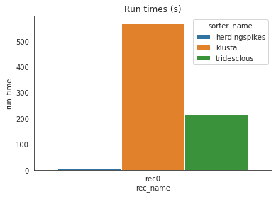

```python
run_times = dataframes['run_times']
fig, ax = plt.subplots()
sns.barplot(data=run_times, x='rec_name', y='run_time', hue='sorter_name', ax=ax)
ax.set_title('Run times (s)')
```

### By unit

The more convinient dataframes is **'perf_by_spiketrain'**.

Here we plot for each sorter the accuracy for each units in the ground truth.

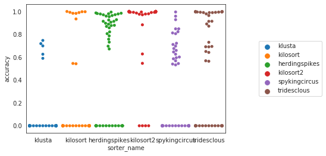

```python
perfs = dataframes['perf_by_unit']
fig, ax = plt.subplots()
g = sns.swarmplot(data=perfs, x='sorter_name', y='accuracy', hue='sorter_name', ax=ax)
g.legend(loc='center right', bbox_to_anchor=(1.5, 0.5))
```

### Accuracy average

```
(0, 1)
```

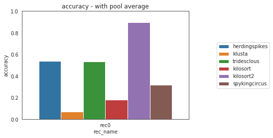

```python
perfs = dataframes['perf_pooled_with_average']
fig, ax = plt.subplots()
g = sns.barplot(data=perfs, x='rec_name', y='accuracy', hue='sorter_name', ax=ax)
g.legend(loc='center right', bbox_to_anchor=(1.5, 0.5))
ax.set_title('accuracy - with pool average')
ax.set_ylim(0, 1)
```

### accuracy vs SNR

Here a plot to see if the high SNR make better accuracy.

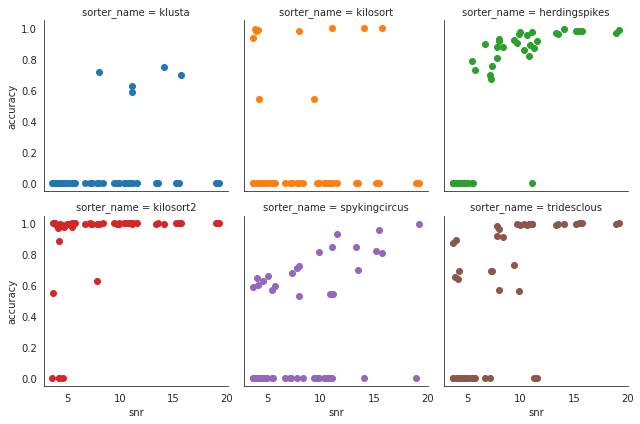

```python
# insert snr columns
perfs = dataframes['perf_by_spiketrain']
perfs['snr'] = perfs['gt_unit_id'].apply(lambda id: snr.loc[id])

grid = sns.FacetGrid(perfs, hue='sorter_name', col='sorter_name', col_wrap=3)
grid.map(plt.plot, 'snr', 'accuracy', marker="o", ls='None')
```

### How many units detected above threshold

The very end question for an experimentalist using software for spike sorting would be, how many cells is it able to detect correctly ? One anwser could be cells with accuracy above a threshold.

For instance here we count how many cells above 0.95 the sorter is able to detect.

The max is 50 cells.

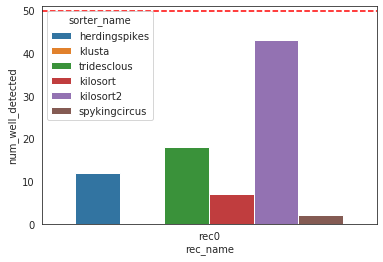

```python
perfs = dataframes['count_units']

fig, ax = plt.subplots()
ax = sns.barplot(data=perfs, x='rec_name', y='num_well_detected', hue='sorter_name', ax=ax)
ax.set_ylim(0, 51)
ax.axhline(50, ls='--', color='red')
```

### How many units should not be detected at all

Here we count "bad_units" meaning how many units detected to not match any units in the GT.

**bad_units** can be split in 2 category:

- false positive units
- redundant detection (units is detected twice or more)

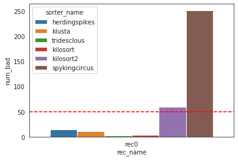

```python
perfs = dataframes['count_units']

fig, ax = plt.subplots()
ax = sns.barplot(data=perfs, x='rec_name', y='num_bad', hue='sorter_name', ax=ax)
ax.axhline(50, ls='--', color='red')
```

## False positive units

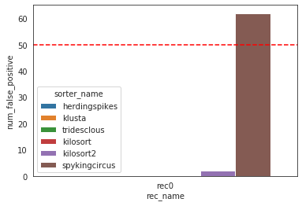

```python
perfs = dataframes['count_units']

fig, ax = plt.subplots()
ax = sns.barplot(data=perfs, x='rec_name', y='num_false_positive', hue='sorter_name', ax=ax)
ax.axhline(50, ls='--', color='red')
```

## redundant detection

Here we count how many units are detected twice or more.

Here again sorter based on template matching have a weakness they produce to much units.

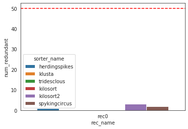

```python
perfs = dataframes['count_units']

fig, ax = plt.subplots()
ax = sns.barplot(data=perfs, x='rec_name', y='num_redundant', hue='sorter_name', ax=ax)
ax.axhline(50, ls='--', color='red')
```

# Conlusion

Comparing sorter is not trivial at all. Counting true positive spike is not enough. We also take in account at units level :

- FN with recall
- FP with precision
- FN and FP with accuracy
- CL msiclaification

But we also need to look at:

- fakse positive units
- redundant detection